# r_graph

## 1.3 그래프의 배열(mfrow)

```
 - 한 창에 여러개의 그래프를 나열하기 위한 방법
 - mfrow를 지정하는 형식은 par(mfrow = c(nr, nc))이다.
 - nr은 행의 수, nc는 열의 수를 뜻한다.
 ex) mfrow=c(1,2) => 한 창에 그래프를 1행 2열로 배치
```

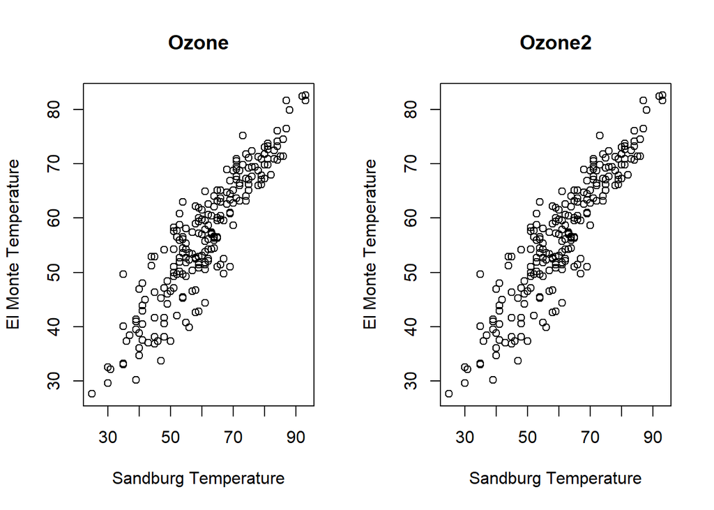

```r
opar <- par(mfrow=c(1,2)) # par()문에 mfrow를 지정, 이전에 저장된 par설정 반환
plot(
  Ozone$V8,
  Ozone$V9,
  xlab="Sandburg Temperature",
  ylab="El Monte Temperature",
  main="Ozone"
)
plot(
  Ozone$V8,
  Ozone$V9,
  xlab="Sandburg Temperature",
  ylab="El Monte Temperature",
  main="Ozone2"
)
```

```r
par(opar) # mfrow 지정 이전의 par 설정으로 되돌린다.
```

## 1.4 지터(jitter)

- Ozone데이터의 V6와 V7은 각각 LAX에서의 풍속과 습도를 담고 있다.
- 이 둘은 자연수로 표시되므로 값이 같은 경우가 많다.
- Jitter는 데이터 값을 조금씩 움직여서 같은 점에 데이터가 여러번 겹쳐서 표시되는 현상을 막는다.

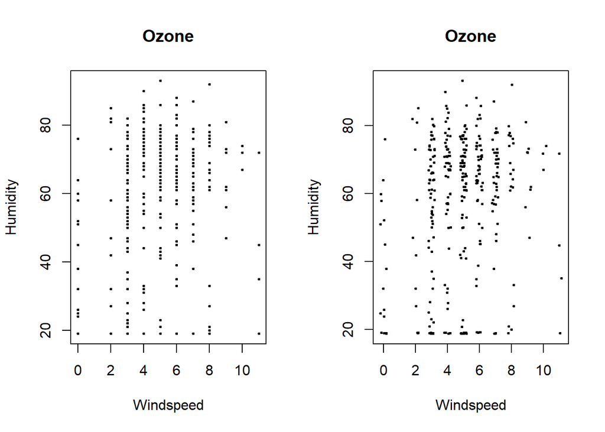

```r
opar <- par(mfrow=c(1,2))
plot(
  Ozone$V6,
  Ozone$V7,
  xlab="Windspeed",
  ylab="Humidity",
  main="Ozone",
  pch=20,
  cex=.5
)
plot(jitter(Ozone$V6),
     jitter(Ozone$V7),
     xlab="Windspeed",
    ylab="Humidity",
    main="Ozone",
    pch=20,
    cex=.5
)
```

```r
par(opar)
```

## 1.5 점(points)

```
 - points()는 점을 그리기 위한 함수
 - plot()을 연달아 호출하는 경우 추가적으로 그려준다.
```

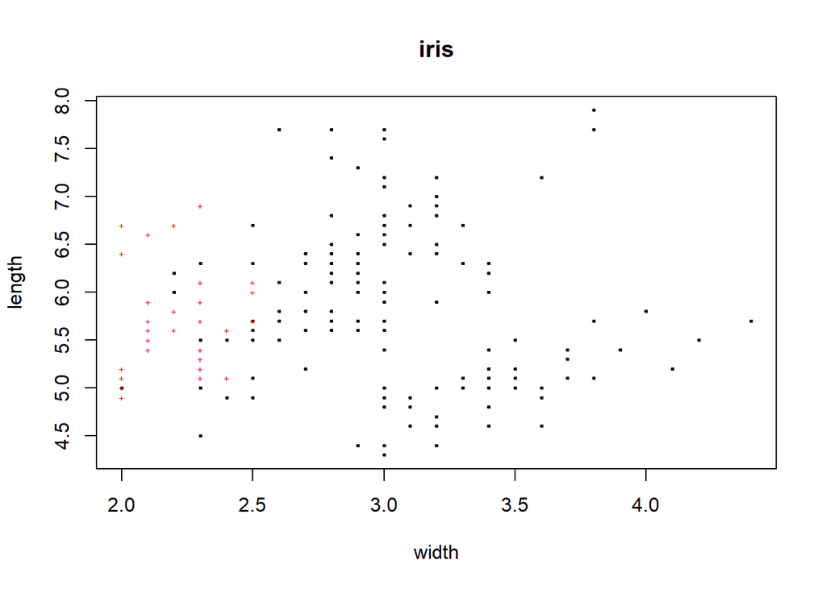

```r
# iris의 Sepal.Width, Sepal.Length을 plot으로 그린 뒤 Petal.Width, Petal.Length을 같은 그래프 위에 덧 그리는 코드
plot(
  iris$Sepal.Width,
  iris$Sepal.Length,
  cex=.5,
  pch=20,
  xlab="width",
  ylab="length",
  main="iris"
)
points(
  iris$Petal.Width,
  iris$Petal.Length,
  cex=.5,
  pch="+",
  col="#FF0000"
)
```

- iris가 연달아 나타날때는 attach()로 데이터를 불러들인 뒤 필드를 곧바로 접근할 수도 있다.

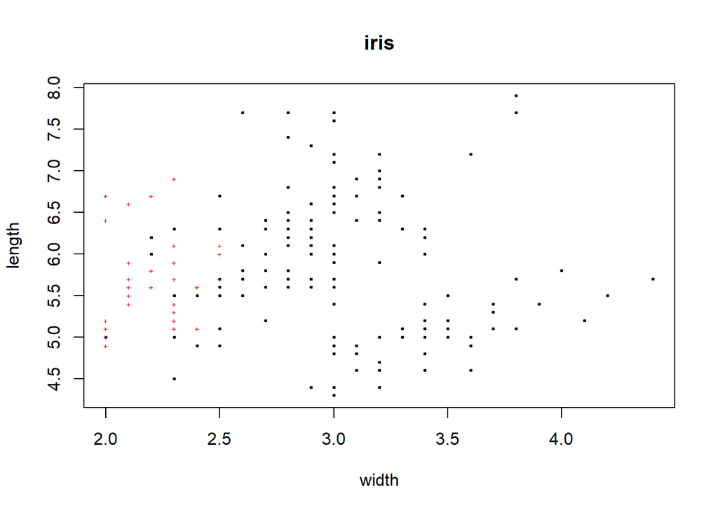

```r
attach(iris)
plot(
  Sepal.Width,
  Sepal.Length,
  cex=.5,
  pch=20,
  xlab="width",
  ylab="length",
  main="iris"
)
points(
  Petal.Width,
  Petal.Length,
  cex=.5,
  pch="+",
  col="#FF0000"
)
```

> 문제점

```
 - attach()한 데이터를 detach()하지 않을경우 Sepal.Length 등이 계속 접근 가능하게 남아있게 된다는 것이다.
 - 데이터를 다시 사용하지 않을 계획이라면 with(), within()에서 본바와 같이 with문을 써서 iris 데이터의 접근 범위를 보다 명시적으로 제한하여 코딩할 수도 있다.
```

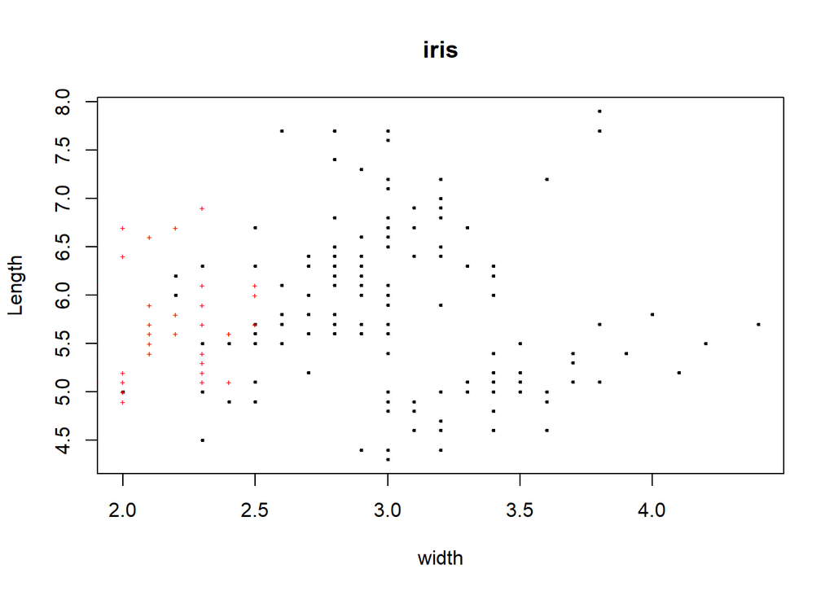

```
 - points()는 이처럼 이미 그려진 plot 에 추가로 점을 표시할 수 있다.
 - 그런데 때에 따라서는 제일 처음 plot() 문을 수행할 때는 그래프에 표시할 데이터가 없다가, 이후 points() 명령을 수행할 시점에 표시할 데이터가 준비될 경우가 있다.
 - 이럴때는 type=“n”을 사용하여 plot()을 수행한다.
 - 그러면 화면에 그려지는 데이터는 없으나 새로운 plot을 시작하여 points() 호출이 가능해진다.
```

```r
with(
  iris,
  {
    plot(
      Sepal.Width,
      Sepal.Length,
      cex=.5,
      pch=20,
      xlab="width",
      ylab="Length",
      main="iris"
      )
    points(
      Petal.Width,
      Petal.Length,
      cex=.5,
      pch="+",
      col="#FF0000"
    )
  }
)
```

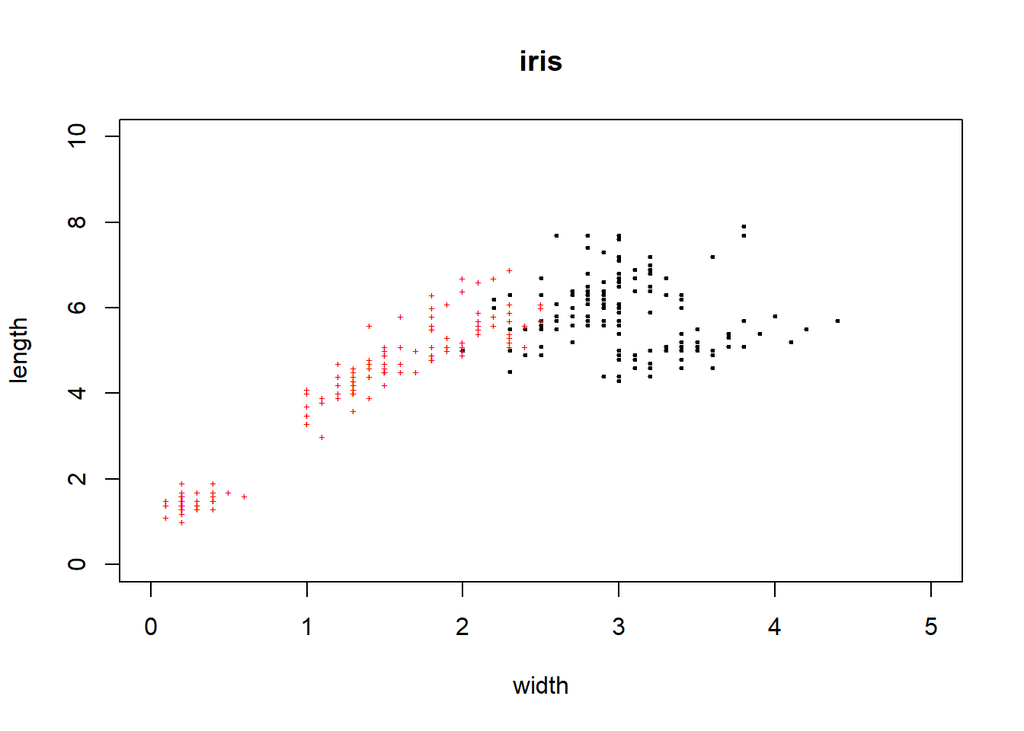

```r
# type="n"을 사용하여 점진적인 방법으로 그래프를 그릴 수 있다.
# 그러나 xlim, ylim을 적절하게 설정해줘야 하는 번거로움이 있다.
with(
  iris,
  {
    plot(
      NULL,
      xlim=c(0, 5),
      ylim=c(0, 10),
      xlab="width",
      ylab="length",
      main="iris",
      type="n"
    )
    points(
      Sepal.Width,
      Sepal.Length,
      cex=.5,
      pch=20
    )
    points(
      Petal.Width,
      Petal.Length,
      cex=.5,
      pch="+",
      col="#FF0000"
    )
  }
)
```

## 1.6 선(lines)

- lines()는 points()와 마찬가지로 plot()으로 새로운 그래프를 그린 뒤 선을 그리는 목적으로 사용된다.

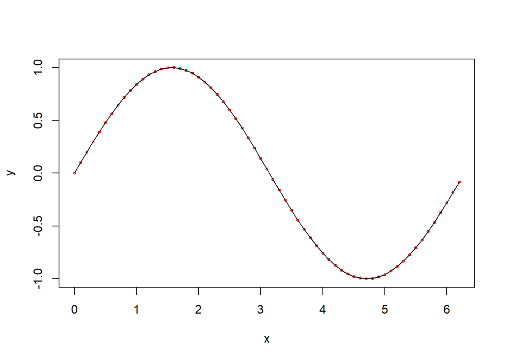

```
 - example(lines)를 입력하면 cars 데이터에 LOWESS를 적용한 예를 볼 수 있다.
 - LOWESS는 데이터의 각 점에서 linear model(y = ax + b) 또는 quadratic model(y = ax2 + bx + c)을 각각 적합하되, 각 점에서 가까운 데이터에 많은 weight를 주면서 egression을 수행한다.
```

```r
x <- seq(0, 2*pi, 0.1)
y <- sin(x)
plot(x, y, cex=.5, col="red")
lines(x, y)
```

> cars 데이터에 대해 LOWESS를 수행

```r
library(mlbench)
data(cars)
head(cars)
```

```
##   speed dist
## 1     4    2
## 2     4   10
## 3     7    4
## 4     7   22
## 5     8   16
## 6     9   10
```

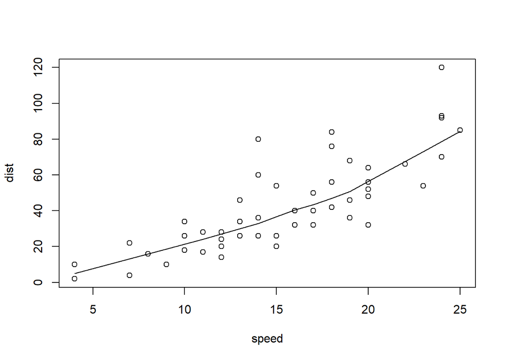

```r
plot(cars)
lines(lowess(cars)) # 각각의 관찰값을 점으로 표시하고, LOWESS를 수행한 결과
```

- R은 이외에도 loess(), ksmooth(), smooth.spline(), earth() 등의 비모수적 회귀 방법을 제공한다.

## 1.7 직선(abline)

- abline은 y = a + bx 형태의 직선, 또는 y = h 형태의 가로로 그은 직선, 또는 x = v 형태의 세로로 그은 직선을 그래프에 그린다.
- abline()을 사용하여 근사가 얼마나 잘 이루어지는지를 시각화 해 볼 수 있다.

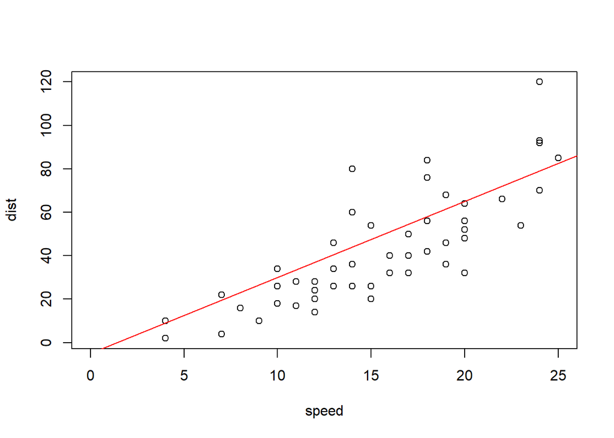

```r
#  cars 데이터가 dist = −5 + 3.5 × speed로 근사될 수 있다고 가정해보자.
plot(
  cars,
  xlim=c(0, 25)
)
abline(
  a=-5,
  b=3.5,
  col="red"
)
```

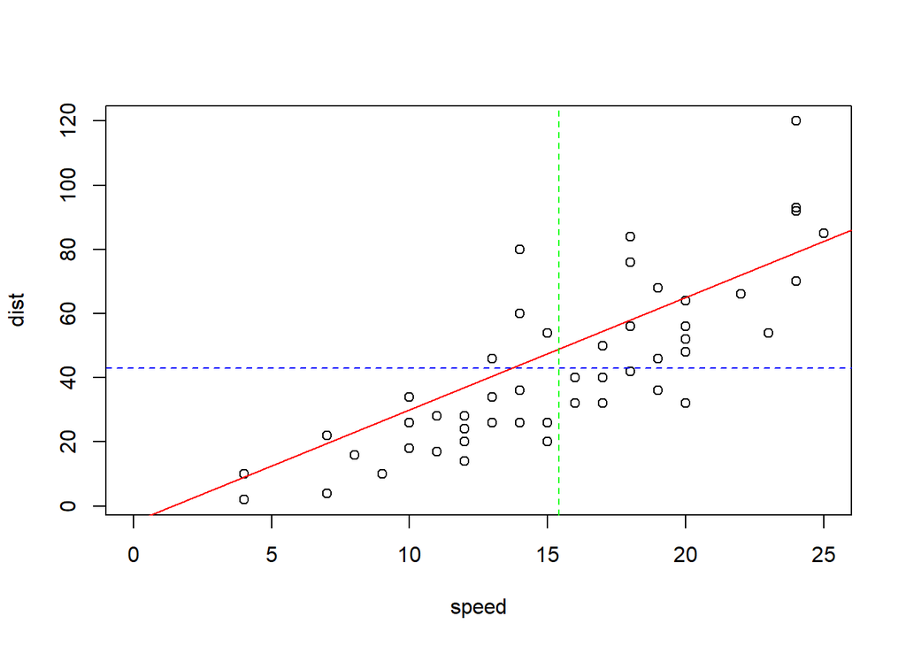

```r
plot(cars, xlim=c(0, 25))
abline(a=-5, b=3.5, col="red")
# lty = 2는 dashed line을 뜻한다.
abline(h=mean(cars$dist), lty=2, col="blue") # dist의 평균
abline(v=mean(cars$speed), lty=2, col="green") # speed의 형균
```

- 그래프를 그려본 결과 dist = −5 + 3.5 × speed는 (x=speed의 평균, y=dist의 평균) 점을 지나지 않는다. 따라서 이 직선은 올바른 선형회귀 직선은 아니다.